# Fun with fractals

PP

## Introduction

Welcome to the [Sierpinski Triangle 3D Visualization App](https://pavel-droid.shinyapps.io/Explore_Sierpinski_Triangles/)!

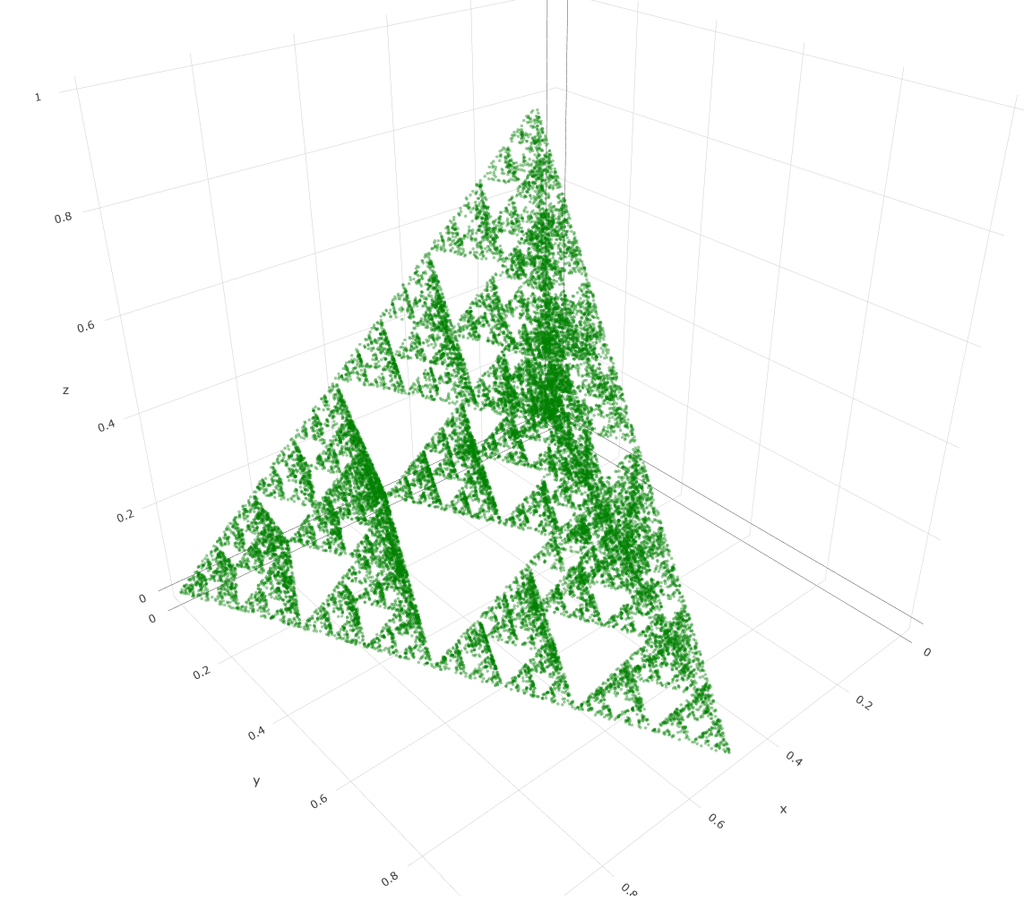

## App overview

- The Sierpinski Triangle 3D Visualization App is designed to provide an interactive experience with fractals, specifically the Sierpinski Triangle.
- Fractals are fascinating mathematical objects that exhibit self-similarity at different scales, and the Sierpinski Triangle is a classic example.
- With this app, you can explore and visualize the intricate patterns generated by fractal mathematics in a three-dimensional space.
- Adjust various parameters to customize your fractal visualization and gain a deeper understanding of this captivating mathematical concept.

## Fractals

- Fractals are captivating mathematical objects characterized by self-similarity at different scales.
- They exhibit complex and intricate patterns that can be generated through recursive algorithms.
- The Sierpinski Triangle, featured in this app, is a well-known fractal.
- Fractals have applications in various fields, including mathematics, physics, computer graphics, and art.
- Exploring fractals can lead to a deeper appreciation of the beauty and complexity of the natural world.

## How to use

- Adjust the “Number of Iterations” slider to control the complexity of the fractal.
- Select a “Point Color” for the dots in the plot.
- Use the “Dot Size” slider to change the size of the dots.
- Control the opacity of the dots with the “Dot Transparency” slider.

## Conclusion

I hope you’ve enjoyed exploring the Sierpinski Triangle 3D Visualization App.

This app provides an engaging way to interact with fractals and discover the mesmerizing patterns they create.

Remember that fractals are not just mathematical concepts; they often appear in nature and have real-world applications.

Continue to experiment with the app and adjust the parameters to uncover the beauty of fractal mathematics.

Thank you for using this app, and I hope it has sparked your curiosity about the world of fractals!